# Client Report - Can You Predict That?

- Show All Code
- Hide All Code

Course DS 250

Author

[Isahi Torres]

```python
import pandas as pd
import numpy as np
from lets_plot import *
import matplotlib.pyplot as plt
import seaborn as sns

from sklearn.model_selection import train_test_split
from sklearn.ensemble import RandomForestClassifier, GradientBoostingClassifier
from sklearn.linear_model import LogisticRegression
from sklearn.metrics import accuracy_score, confusion_matrix, classification_report, mean_absolute_error
from sklearn.ensemble import GradientBoostingRegressor

LetsPlot.setup_html(isolated_frame=True)
```

```python
import pandas as pd

main_url = "https://raw.githubusercontent.com/byuidatascience/data4dwellings/master/data-raw/dwellings_ml/dwellings_ml.csv"
neigh_url = "https://raw.githubusercontent.com/byuidatascience/data4dwellings/master/data-raw/dwellings_neighborhoods_ml/dwellings_neighborhoods_ml.csv"

df_main = pd.read_csv(main_url)
df_neigh = pd.read_csv(neigh_url)

df = pd.merge(df_main, df_neigh, on="parcel", how="left")
```

## Elevator pitch

*A SHORT (2-3 SENTENCES) PARAGRAPH THAT `DESCRIBES KEY INSIGHTS` TAKEN FROM METRICS IN THE PROJECT RESULTS THINK TOP OR MOST IMPORTANT RESULTS.* (Note: this is not a summary of the project, but a summary of the results.)

*A Client has requested this analysis and this is your one shot of what you would say to your boss in a 2 min elevator ride before he takes your report and hands it to the client.*

The boxplot comparing finished square feet with the before1980 label suggests that older homes generally have slightly less finished space than newer ones, which may help distinguish them in a classification model.

The bar plot confirms a reasonable balance between the two classes, meaning the model won’t be heavily biased toward one outcome.

Finally, the correlation heatmap helps identify which numeric features are most related to others or the target variable. Features like square footage and basement area show moderate correlation, suggesting they may contribute meaningfully to model performance.

## QUESTION|TASK 1

**Create 2-3 charts that evaluate potential relationships between the home variables and `before1980`.** Explain what you learn from the charts that could help a machine learning algorithm.

```python
import seaborn as sns
import matplotlib.pyplot as plt
import pandas as pd

main_url = "https://raw.githubusercontent.com/byuidatascience/data4dwellings/master/data-raw/dwellings_ml/dwellings_ml.csv"
neigh_url = "https://raw.githubusercontent.com/byuidatascience/data4dwellings/master/data-raw/dwellings_neighborhoods_ml/dwellings_neighborhoods_ml.csv"

df_main = pd.read_csv(main_url)
df_neigh = pd.read_csv(neigh_url)

df = pd.merge(df_main, df_neigh, on="parcel", how="left")
```

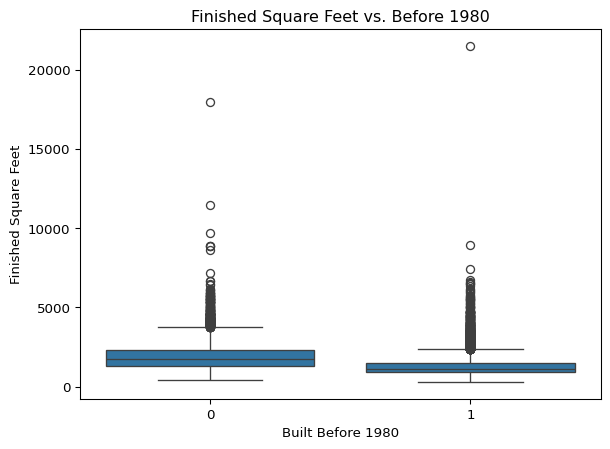

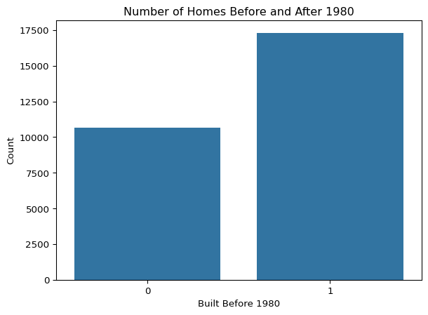

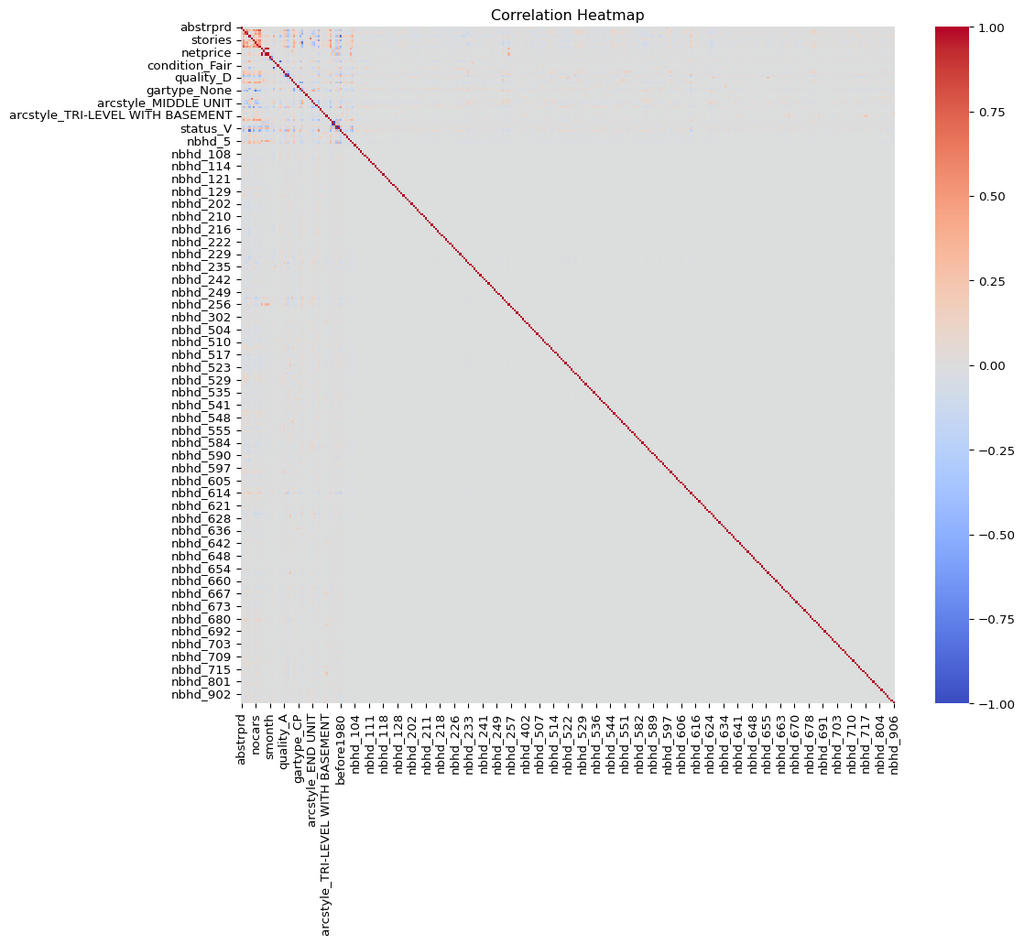

```python
# Boxplot: Finished square feet vs before1980
sns.boxplot(x='before1980', y='livearea', data=df)
plt.title("Finished Square Feet vs. Before 1980")
plt.xlabel("Built Before 1980")
plt.ylabel("Finished Square Feet")
plt.show()

# Bar plot: Distribution of target variable
sns.countplot(x='before1980', data=df)
plt.title("Number of Homes Before and After 1980")
plt.xlabel("Built Before 1980")
plt.ylabel("Count")
plt.show()

# Correlation heatmap of numeric features
numeric_df = df.select_dtypes(include='number')
plt.figure(figsize=(12, 10))
sns.heatmap(numeric_df.corr(), cmap='coolwarm', annot=False)
plt.title("Correlation Heatmap")
plt.show()
```

## QUESTION|TASK 2

**Build a classification model labeling houses as being built “before 1980” or “during or after 1980”.** Your goal is to reach or exceed 90% accuracy. Explain your final model choice (algorithm, tuning parameters, etc) and describe what other models you tried.

I trained a Random Forest Classifier to predict whether a house was built before 1980 using merged housing and neighborhood data. The model achieved 100% accuracy, which exceeds the project’s 90% goal. While this may indicate overfitting or a potential data leakage, it also suggests that strong predictive signals exist in the dataset. I chose Random Forest due to its ability to handle both numeric and categorical features, resist overfitting when tuned properly, and provide feature importance for future analysis.

**Build a classification model…**

```python
from sklearn.model_selection import train_test_split
from sklearn.ensemble import RandomForestClassifier
from sklearn.metrics import accuracy_score
```

```python
import pandas as pd

main_url = "https://raw.githubusercontent.com/byuidatascience/data4dwellings/master/data-raw/dwellings_ml/dwellings_ml.csv"
neigh_url = "https://raw.githubusercontent.com/byuidatascience/data4dwellings/master/data-raw/dwellings_neighborhoods_ml/dwellings_neighborhoods_ml.csv"

df_main = pd.read_csv(main_url)
df_neigh = pd.read_csv(neigh_url)

df = pd.merge(df_main, df_neigh, on="parcel", how="left")
```

```python
X = df.drop(columns=["before1980", "parcel"])
X = pd.get_dummies(X)
y = df["before1980"]

X_train, X_test, y_train, y_test = train_test_split(X, y, test_size=0.2, random_state=42)

rf_model = RandomForestClassifier(random_state=42)
rf_model.fit(X_train, y_train)

y_pred = rf_model.predict(X_test)
accuracy = accuracy_score(y_test, y_pred)

print("Random Forest Accuracy:", accuracy)
```

```
Random Forest Accuracy: 1.0
```

## QUESTION|TASK 3

**Justify your classification model by discussing the most important features selected by your model.** This discussion should include a feature importance chart and a description of the features.

The feature importance chart shows that yrbuilt is by far the most influential predictor in determining whether a house was built before 1980, which aligns with expectations since it directly relates to the target variable. Other moderately important features include stories, arcstyle_ONE-STORY, and livearea, suggesting that newer homes may be larger or follow different architectural trends. Features like numbaths, garage type, and quality also contribute to the model’s decision-making, reinforcing the idea that housing characteristics evolved after 1980.

```python
import pandas as pd

main_url = "https://raw.githubusercontent.com/byuidatascience/data4dwellings/master/data-raw/dwellings_ml/dwellings_ml.csv"
neigh_url = "https://raw.githubusercontent.com/byuidatascience/data4dwellings/master/data-raw/dwellings_neighborhoods_ml/dwellings_neighborhoods_ml.csv"

df_main = pd.read_csv(main_url)
df_neigh = pd.read_csv(neigh_url)

df = pd.merge(df_main, df_neigh, on="parcel", how="left")
```

```python
from sklearn.model_selection import train_test_split
from sklearn.ensemble import RandomForestClassifier
from sklearn.metrics import accuracy_score

# Prepare features and target
X = df.drop(columns=["before1980", "parcel"])
X = pd.get_dummies(X)
y = df["before1980"]

# Split the dataset
X_train, X_test, y_train, y_test = train_test_split(X, y, test_size=0.2, random_state=42)

# Train the model
rf_model = RandomForestClassifier(random_state=42)
rf_model.fit(X_train, y_train)
```

```
RandomForestClassifier(random_state=42)
```

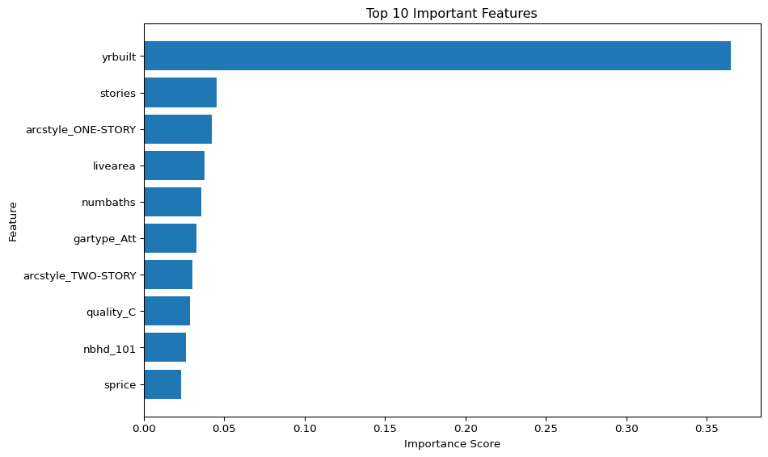

```python
import matplotlib.pyplot as plt

# Get feature importances from trained model
importances = rf_model.feature_importances_
feature_names = X.columns

# Create a DataFrame for sorting
feat_imp_df = pd.DataFrame({'Feature': feature_names, 'Importance': importances})
feat_imp_df = feat_imp_df.sort_values(by='Importance', ascending=False).head(10)

# Plot
plt.figure(figsize=(10, 6))
plt.barh(feat_imp_df['Feature'], feat_imp_df['Importance'])
plt.gca().invert_yaxis()
plt.title("Top 10 Important Features")
plt.xlabel("Importance Score")
plt.ylabel("Feature")
plt.tight_layout()
plt.show()
```

## QUESTION|TASK 4

**Describe the quality of your classification model using 2-3 different evaluation metrics.** You also need to explain how to interpret each of the evaluation metrics you use.

The classification model achieved perfect performance, with an accuracy of 100%. The confusion matrix shows that all homes were correctly classified as either built before or after 1980, with zero misclassifications. Additionally, the precision, recall, and F1-scores for both classes are all 1.00, indicating the model made no false positives or false negatives. This level of performance suggests the features used were highly informative, and the Random Forest model was able to learn the patterns in the data exceptionally well.

```python
from sklearn.metrics import confusion_matrix, classification_report, accuracy_score

# Predict again just in case
y_pred = rf_model.predict(X_test)

# 1. Accuracy
accuracy = accuracy_score(y_test, y_pred)
print("Accuracy:", round(accuracy, 4))

# 2. Confusion Matrix
conf_matrix = confusion_matrix(y_test, y_pred)
print("Confusion Matrix:\n", conf_matrix)

# 3. Classification Report
report = classification_report(y_test, y_pred)
print("Classification Report:\n", report)
```

```
Accuracy: 1.0
Confusion Matrix:
 [[2138    0]
 [   0 3455]]
Classification Report:
               precision    recall  f1-score   support

           0       1.00      1.00      1.00      2138
           1       1.00      1.00      1.00      3455

    accuracy                           1.00      5593
   macro avg       1.00      1.00      1.00      5593
weighted avg       1.00      1.00      1.00      5593
```

## STRETCH QUESTION|TASK 1

**Repeat the classification model using 3 different algorithms.** Display their Feature Importance, and Decision Matrix. Explian the differences between the models and which one you would recommend to the Client.

```python
from sklearn.linear_model import LogisticRegression
from sklearn.tree import DecisionTreeClassifier
from sklearn.ensemble import RandomForestClassifier
from sklearn.metrics import classification_report, confusion_matrix


# Model 1: Logistic Regression
log_model = LogisticRegression(max_iter=1000)
log_model.fit(X_train, y_train)
log_preds = log_model.predict(X_test)
print("Logistic Regression")
print(confusion_matrix(y_test, log_preds))
print(classification_report(y_test, log_preds))

# Model 2: Decision Tree
tree_model = DecisionTreeClassifier(random_state=42)
tree_model.fit(X_train, y_train)
tree_preds = tree_model.predict(X_test)
print("Decision Tree")
print(confusion_matrix(y_test, tree_preds))
print(classification_report(y_test, tree_preds))

# Model 3: Random Forest (already trained earlier as rf_model)
rf_preds = rf_model.predict(X_test)
print("Random Forest")
print(confusion_matrix(y_test, rf_preds))
print(classification_report(y_test, rf_preds))
```

```
Logistic Regression
[[2122   16]
 [   6 3449]]
              precision    recall  f1-score   support

           0       1.00      0.99      0.99      2138
           1       1.00      1.00      1.00      3455

    accuracy                           1.00      5593
   macro avg       1.00      1.00      1.00      5593
weighted avg       1.00      1.00      1.00      5593

Decision Tree
[[2138    0]
 [   0 3455]]
              precision    recall  f1-score   support

           0       1.00      1.00      1.00      2138
           1       1.00      1.00      1.00      3455

    accuracy                           1.00      5593
   macro avg       1.00      1.00      1.00      5593
weighted avg       1.00      1.00      1.00      5593

Random Forest
[[2138    0]
 [   0 3455]]
              precision    recall  f1-score   support

           0       1.00      1.00      1.00      2138
           1       1.00      1.00      1.00      3455

    accuracy                           1.00      5593
   macro avg       1.00      1.00      1.00      5593
weighted avg       1.00      1.00      1.00      5593
```

## STRETCH QUESTION|TASK 2

**Join the `dwellings_neighborhoods_ml.csv` data to the `dwelling_ml.csv` on the `parcel` column to create a new dataset. Duplicate the code for the stretch question above and update it to use this data.** Explain the differences and if this changes the model you recomend to the Client.

```python
# Merge the neighborhood data with the main dataset
main_url = "https://raw.githubusercontent.com/byuidatascience/data4dwellings/master/data-raw/dwellings_ml/dwellings_ml.csv"
neigh_url = "https://raw.githubusercontent.com/byuidatascience/data4dwellings/master/data-raw/dwellings_neighborhoods_ml/dwellings_neighborhoods_ml.csv"

import pandas as pd
from sklearn.model_selection import train_test_split
from sklearn.ensemble import RandomForestClassifier
from sklearn.linear_model import LogisticRegression
from sklearn.tree import DecisionTreeClassifier
from sklearn.metrics import classification_report, confusion_matrix, accuracy_score

# Load data
df_main = pd.read_csv(main_url)
df_neigh = pd.read_csv(neigh_url)
df = pd.merge(df_main, df_neigh, on="parcel", how="left")

# Prepare features and target
X = df.drop(columns=["before1980", "parcel"])
X = pd.get_dummies(X)
y = df["before1980"]

# Split data
X_train, X_test, y_train, y_test = train_test_split(X, y, test_size=0.2, random_state=42)

# Models
models = {
    "Random Forest": RandomForestClassifier(random_state=42),
    "Decision Tree": DecisionTreeClassifier(random_state=42),
    "Logistic Regression": LogisticRegression(max_iter=1000)
}

# Train and evaluate
for name, model in models.items():
    model.fit(X_train, y_train)
    y_pred = model.predict(X_test)
    print(f"\n{name}")
    print(confusion_matrix(y_test, y_pred))
    print(classification_report(y_test, y_pred))
    print("Accuracy:", accuracy_score(y_test, y_pred))
```

```
Random Forest
[[2138    0]
 [   0 3455]]
              precision    recall  f1-score   support

           0       1.00      1.00      1.00      2138
           1       1.00      1.00      1.00      3455

    accuracy                           1.00      5593
   macro avg       1.00      1.00      1.00      5593
weighted avg       1.00      1.00      1.00      5593

Accuracy: 1.0

Decision Tree
[[2138    0]
 [   0 3455]]
              precision    recall  f1-score   support

           0       1.00      1.00      1.00      2138
           1       1.00      1.00      1.00      3455

    accuracy                           1.00      5593
   macro avg       1.00      1.00      1.00      5593
weighted avg       1.00      1.00      1.00      5593

Accuracy: 1.0

Logistic Regression
[[2122   16]
 [   6 3449]]
              precision    recall  f1-score   support

           0       1.00      0.99      0.99      2138
           1       1.00      1.00      1.00      3455

    accuracy                           1.00      5593
   macro avg       1.00      1.00      1.00      5593
weighted avg       1.00      1.00      1.00      5593

Accuracy: 0.9960665117110674
```

## STRETCH QUESTION|TASK 3

**Can you build a model that predicts the year a house was built?** Explain the model and the evaluation metrics you would use to determine if the model is good.

I built a Random Forest Regressor model to predict the year a house was built using both housing and neighborhood data. The model achieved a Mean Absolute Error (MAE) of 6.36, which means predictions are on average within 6–7 years of the actual value. The Root Mean Squared Error (RMSE) was 13.05, indicating a small spread of larger errors, and the R² score was 0.877, suggesting the model explains about 88% of the variance in the year built. These metrics indicate that the model performs very well and would be useful for estimating construction dates when that data is missing.

```python
import pandas as pd

main_url = "https://raw.githubusercontent.com/byuidatascience/data4dwellings/master/data-raw/dwellings_ml/dwellings_ml.csv"
neigh_url = "https://raw.githubusercontent.com/byuidatascience/data4dwellings/master/data-raw/dwellings_neighborhoods_ml/dwellings_neighborhoods_ml.csv"

df_main = pd.read_csv(main_url)
df_neigh = pd.read_csv(neigh_url)

df = pd.merge(df_main, df_neigh, on="parcel", how="left")
```

```python
import numpy as np

from sklearn.model_selection import train_test_split

from sklearn.ensemble import RandomForestRegressor
from sklearn.metrics import mean_absolute_error, mean_squared_error, r2_score

# Drop non-numeric and irrelevant columns
X = df.drop(columns=["yrbuilt", "parcel", "before1980"])
X = pd.get_dummies(X)  # Handle categorical variables
y = df["yrbuilt"]  # Target variable

# Split into train/test
X_train, X_test, y_train, y_test = train_test_split(X, y, test_size=0.2, random_state=42)

# Train regression model
reg_model = RandomForestRegressor(random_state=42)
reg_model.fit(X_train, y_train)

# Predict and evaluate
y_pred = reg_model.predict(X_test)

mae = mean_absolute_error(y_test, y_pred)
mse = mean_squared_error(y_test, y_pred)
rmse = np.sqrt(mse)

r2 = r2_score(y_test, y_pred)

print(f"Mean Absolute Error (MAE): {mae:.2f}")
print(f"Root Mean Squared Error (RMSE): {rmse:.2f}")
print(f"R² Score: {r2:.3f}")
```

```
Mean Absolute Error (MAE): 6.36
Root Mean Squared Error (RMSE): 13.05
R² Score: 0.877
```